# Análise da rede de relatorias na CFT, de 1995 a 2019

07/10/2019

# Apresentação

Este documento descreve alguns padrões na rede partidária de relatorias na CFT desde 1995 na Câmara. Para a análise, o histórico de todas as proposições movimentadas na CFT foi extraído da nova [API de Dados Abertos da Câmara](https://dadosabertos.camara.leg.br/).[^1].

523 Deputados(as) Federais foram designados(as) para a relatoria de 5709 proposições (considerando apenas PEC, PL, PLP e MPV, seguindo a seleção que normalmente fazemos no OLB) únicas, em um total de 10549 designações de relator feitas na CFT. As demais seções do documento examinam detalhadamente essa rede.

Para facilitar a comparação entre governos, as análises abaixo levam em conta apenas os 9 primeiros meses (i.e., 270 dias) de mandato de cada um dos seguintes mandatos presidenciais:

- Fernando Henrique I (1995-02-22 a 1995-11-19);
- Fernando Henrique II (1999-02-01 a 1999-10-29);
- Lula I (2003-02-01 a 2003-10-29);
- Lula II (2007-02-01 a 2007-10-29);
- Dilma I (2011-02-01 a 2011-10-29);
- Dilma II (2015-02-01 a 2015-10-29);
- Temer (2016-05-12 a 2017-02-06);
- Bolsonaro (2019-02-01 até hoje).

# Relatorias da CFT por mandato

O gráfico abaixo exibe o número de relatorias designadas na CFT nos nove primeiros meses de cada mandato presidencial.

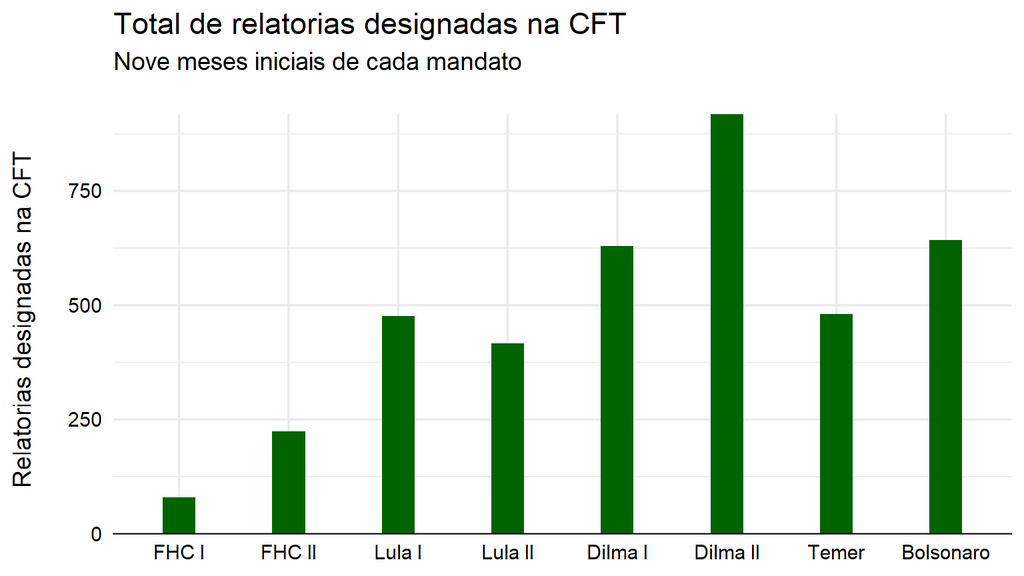

# A rede de relatorias

Os gráficos abaixo exibem a rede de relatorias por partido. Cada ponto (ou vértice) indica um partido, e o tamanho é proporcional ao número de relatorias concentrada por cada partido na CFT.

## FHC I

Nesse período de nove meses, o partido mais central na rede de relatorias da CFT – o partido que mais recebeu relatorias – foi o PFL, com 26, seguido do PMDB, com 16.

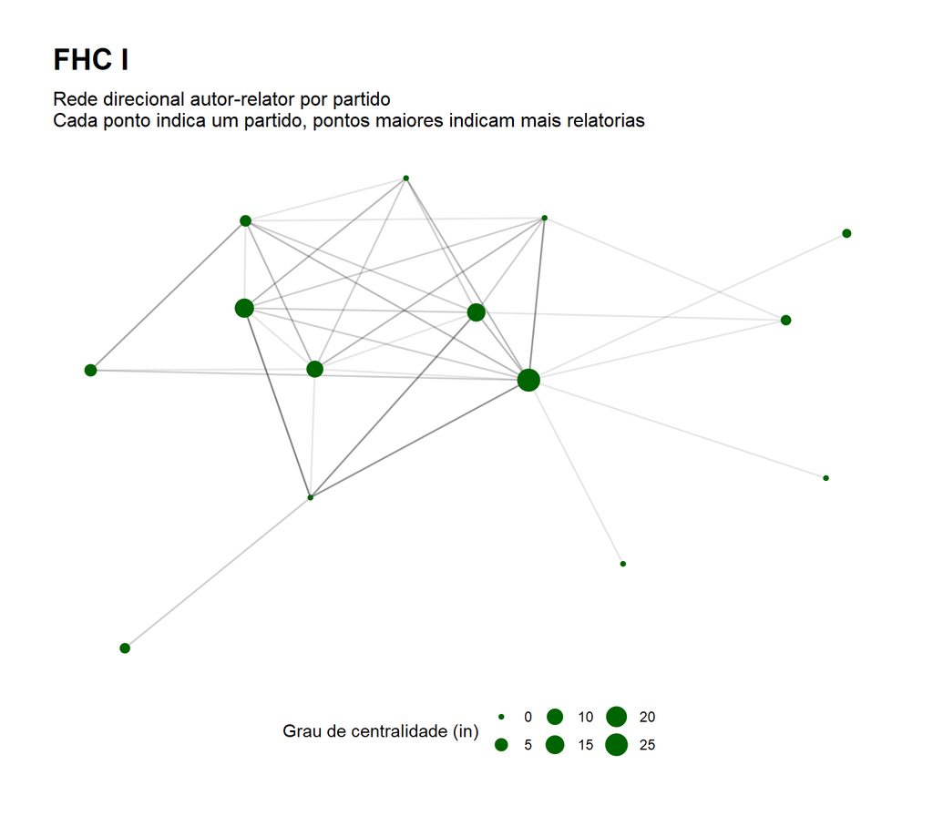

## FHC II

No FHC II, o PFL continua sendo o partido mais central da rede, com 84 relatorias, seguido do PMDB, com 36.

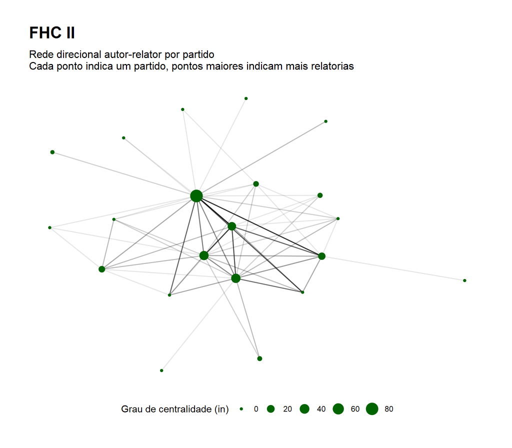

## Lula I

No Lula I o partido mais central continua sendo o PFL/DEM, que concentra 96 relatorias das distribuídas no período de nove meses. O PSDB, segundo partido mais central, relatou apenas 73 proposições.

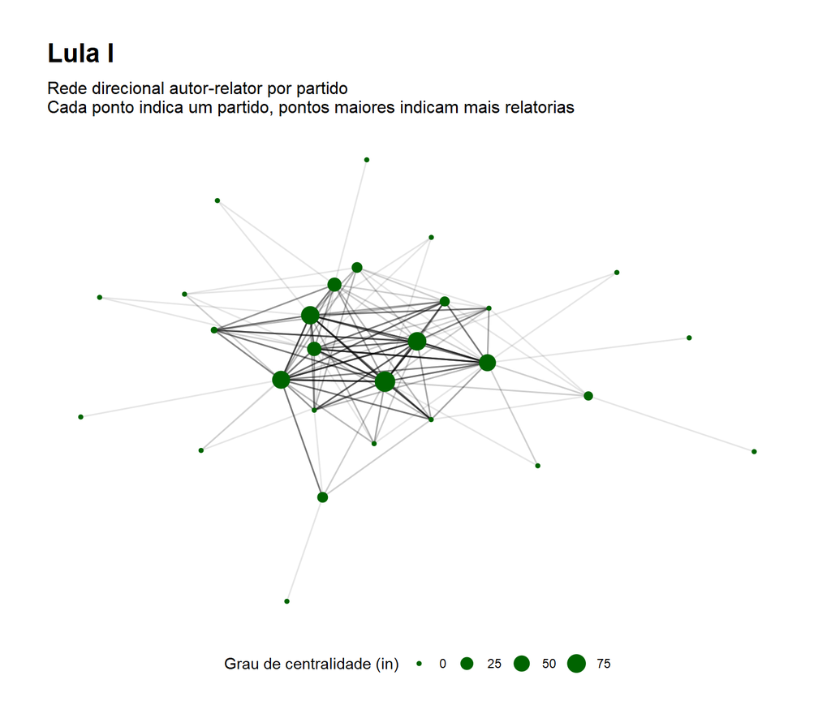

## Lula II

No Lula II, o PT ganha centralidade, relatando 101 proposições. PMDB aparece com 93, PSDB com 42, e DEM com apenas 36.

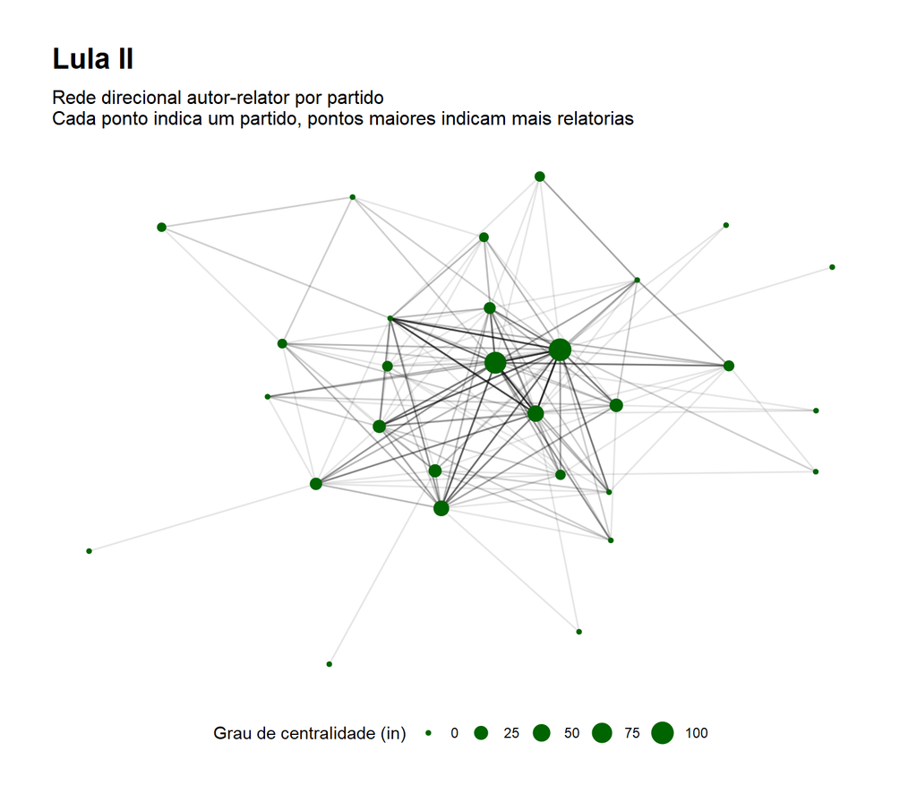

## Dilma I

No Dilma I, o PT desponta: o partido concentrou 264 relatorias contra 58 do PP, o segundo partido mais central.

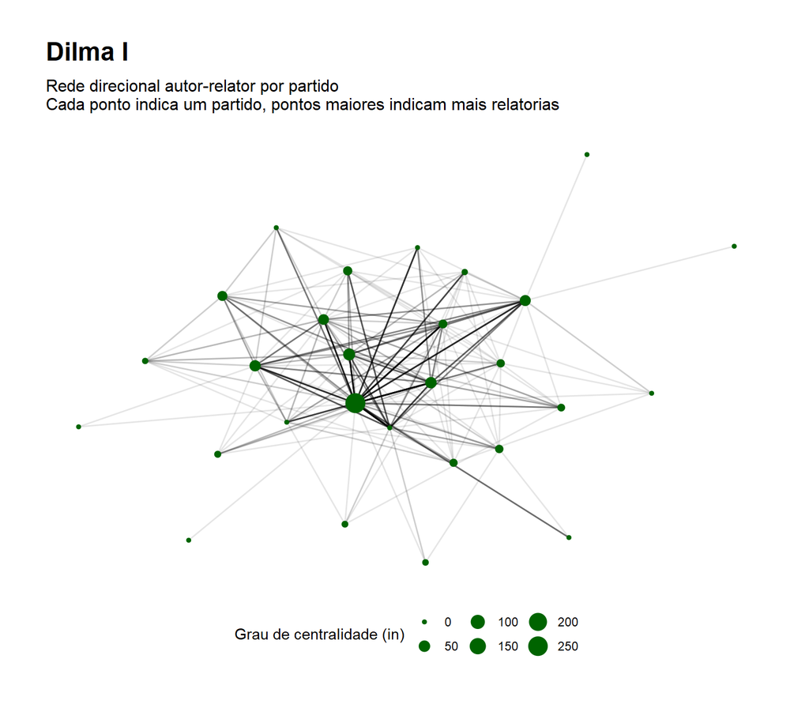

## Dilma II

Durante o Dilma II, o PMDB relata 209 proposições, seguido do DEM (139), PSDB (120). PT aparece com 106.

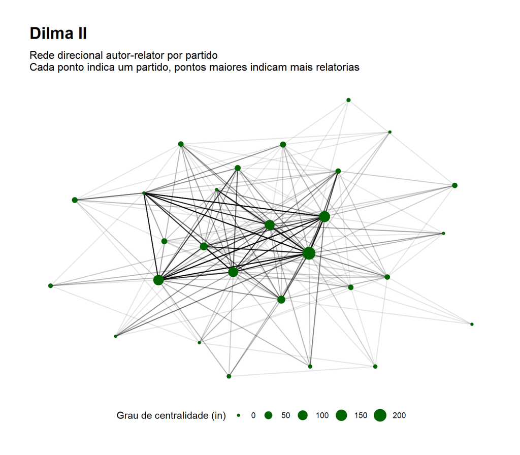

## Temer

No Governo Temer, PMDB relata 104 proposições, contra 69 de PP e PSDB.

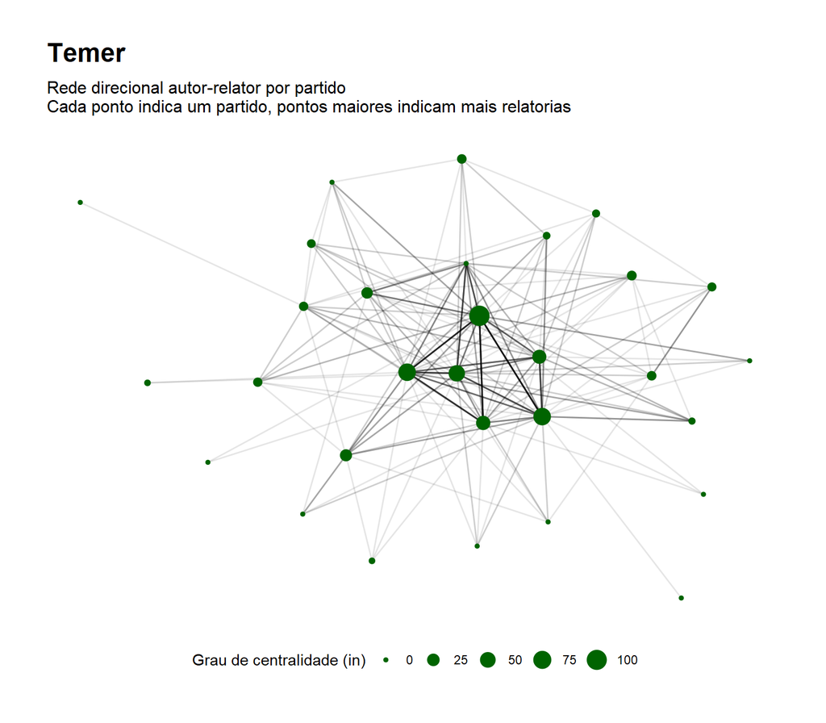

## Bolsonaro

Com Bolsonaro, o MDB continua sendo o ator mais central da rede de relatorias da CFT: 142 proposições relatadas. DEM (79), PP (62), PSL (55) e PSDB (48) completam a lista de partidos mais centrais.

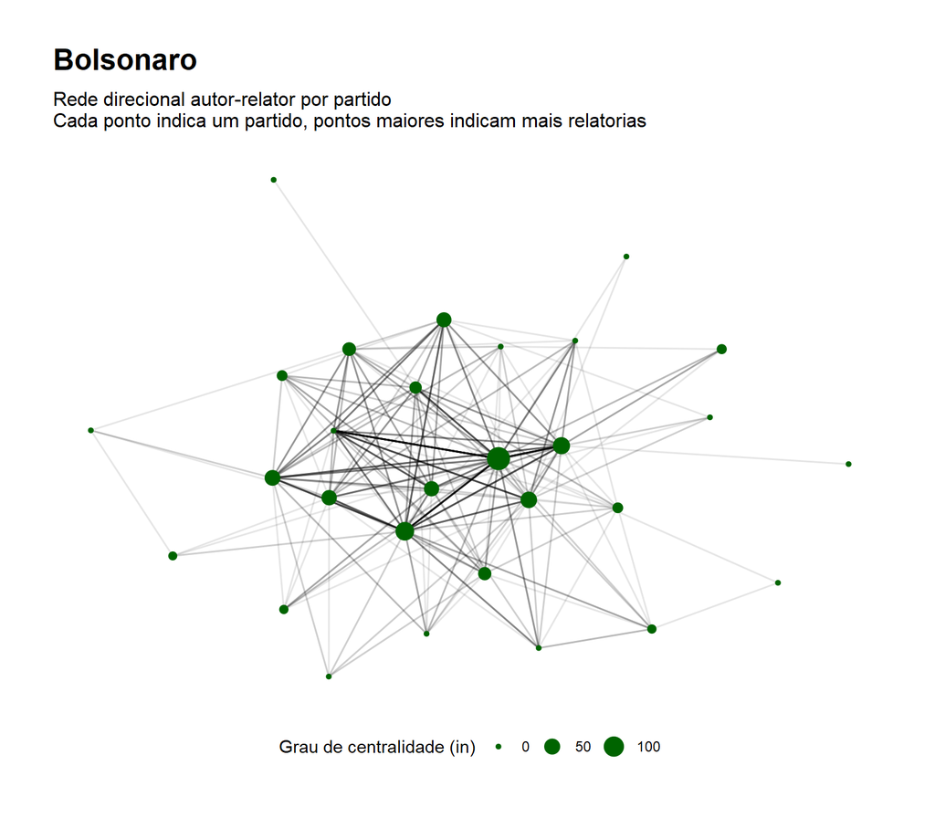

# Relatorias por partido

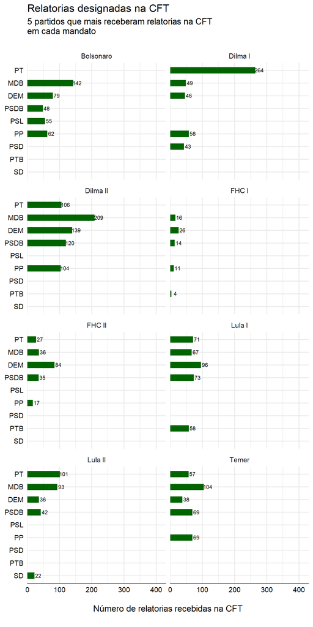

# Relatorias de projetos da Presidência

No gráfico abaixo, é exibido o número de relatorias recebidas por partido de projetos apresentados pelo Poder Executivo, incluindo Presidência da República e seus ministérios.

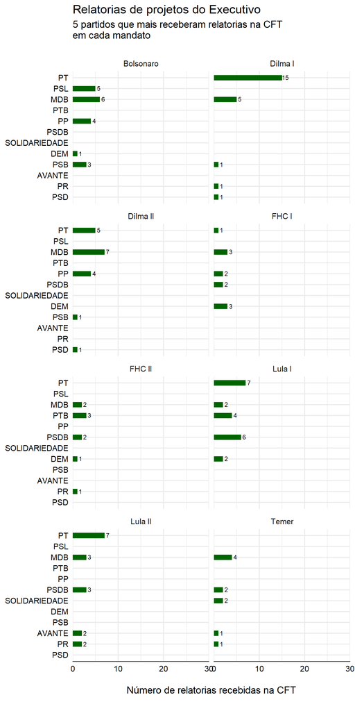

# Proposições da oposição

As tabelas abaixo reportam o número de proposições apresentadas pelos principais partidos de oposição em cada mandato presidencial, nos seus primeiros nove meses, que tiveram relatorias designadas na CFT.

## FHC I

Relatorias recebidas oriundas de projetos apresentados pela oposição: PT e PDT

| Partido relator | PT |
| --- | --- |
| DEM | 3 |
| MDB | 1 |
| PP | 3 |
| PSDB | 1 |
| PTB | 4 |

## FHC II

Relatorias recebidas oriundas de projetos apresentados pela oposição: PT e PDT

| Partido relator | PDT | PT |
| --- | --- | --- |
| DEM | 2 | 18 |
| MDB | 3 | 5 |
| PP | 1 | 4 |
| PR | 1 | 0 |
| PSD | 0 | 1 |
| PSDB | 2 | 10 |
| PT | 1 | 1 |
| PTB | 0 | 2 |

## Lula I

Relatorias recebidas oriundas de projetos apresentados pela oposição: PSDB e PFL

| Partido relator | DEM | PSDB |
| --- | --- | --- |
| DEM | 6 | 6 |
| MDB | 1 | 3 |
| PP | 1 | 1 |
| PPS | 1 | 0 |
| PSB | 0 | 2 |
| PSD | 1 | 1 |
| PSDB | 1 | 3 |
| PT | 3 | 4 |
| PTB | 1 | 2 |

## Lula II

Relatorias recebidas oriundas de projetos apresentados pela oposição: PSDB e PFL

| Partido relator | DEM | PSDB |
| --- | --- | --- |
| AVANTE | 2 | 0 |
| DEM | 6 | 3 |
| MDB | 6 | 11 |
| PP | 0 | 1 |
| PPS | 0 | 1 |
| PR | 2 | 2 |
| PSC | 0 | 1 |
| PSD | 2 | 2 |
| PSDB | 3 | 2 |
| PSOL | 1 | 0 |
| PT | 6 | 14 |
| PTB | 1 | 2 |
| SD | 2 | 1 |

## Dilma I

Relatorias recebidas oriundas de projetos apresentados pela oposição: PSDB e PFL

| Partido relator | DEM | PSDB |
| --- | --- | --- |
| CIDADANIA | 1 | 1 |
| DEM | 3 | 5 |
| MDB | 2 | 5 |
| PDT | 1 | 0 |
| PP | 2 | 2 |
| PR | 1 | 1 |
| PROS | 1 | 0 |
| PSB | 3 | 2 |
| PSD | 0 | 7 |
| PSDB | 0 | 2 |
| PSOL | 0 | 1 |
| PT | 11 | 29 |
| S.PART. | 3 | 4 |
| SD | 1 | 1 |

## Dilma II

Relatorias recebidas oriundas de projetos apresentados pela oposição: PSDB e PFL

| Partido relator | DEM | PSDB |
| --- | --- | --- |
| DEM | 19 | 23 |
| MDB | 17 | 10 |
| PATRI | 3 | 0 |
| PCdoB | 3 | 0 |
| PDT | 2 | 0 |
| PP | 4 | 9 |
| PR | 1 | 1 |
| PRB | 3 | 0 |
| PSB | 4 | 3 |
| PSC | 1 | 0 |
| PSD | 3 | 5 |
| PSDB | 9 | 28 |
| PSOL | 0 | 1 |
| PT | 2 | 8 |
| PTB | 0 | 1 |
| PV | 0 | 2 |
| SOLIDARIEDADE | 0 | 1 |

## Temer

Relatorias recebidas oriundas de projetos apresentados pela oposição: PT, PCdoB e PSOL

| Partido relator | PCdoB | PSOL | PT |
| --- | --- | --- | --- |
| AVANTE | 0 | 0 | 2 |
| DEM | 0 | 0 | 1 |
| MDB | 4 | 1 | 4 |
| PHS | 0 | 0 | 1 |
| PP | 1 | 0 | 5 |
| PR | 0 | 0 | 1 |
| PSB | 0 | 0 | 2 |
| PSC | 0 | 0 | 1 |
| PSD | 1 | 0 | 2 |
| PSDB | 0 | 0 | 5 |
| PSOL | 0 | 0 | 1 |
| PT | 2 | 0 | 5 |
| SOLIDARIEDADE | 0 | 1 | 0 |

## Bolsonaro

Relatorias recebidas oriundas de projetos apresentados pela oposição: PT, PCdoB e PSOL

| Partido relator | PCdoB | PSOL | PT |
| --- | --- | --- | --- |
| CIDADANIA | 0 | 0 | 3 |
| DEM | 4 | 0 | 2 |
| MDB | 3 | 1 | 6 |
| NOVO | 1 | 0 | 2 |
| PDT | 0 | 1 | 2 |
| PP | 2 | 1 | 2 |
| PSB | 0 | 0 | 1 |
| PSC | 0 | 0 | 1 |
| PSD | 1 | 0 | 3 |
| PSDB | 3 | 0 | 2 |
| PSL | 1 | 2 | 1 |
| PT | 1 | 1 | 10 |
| SOLIDARIEDADE | 0 | 0 | 3 |

[^1]: Usei o pacote em `R` que criei para o OLB na coleta: https://fmeireles.com/pacote/